# Life Expectancy and Health Expeditures by Country

Jorge Paramo, Aldo Carranza, Kevin Nievera

Spring 2015

- Data sets can be found on the World Health Organization website
  - Health Expenditures: http://apps.who.int/gho/data/view.main.1920ALL?lang=en
  - Life Expectancy: http://apps.who.int/gho/data/view.main.680

The following are previews of the datasets used for this project.

*Load DataSets*

```r
source("../01 Data/data.R", echo=FALSE)
```

Health Expenditures by Country

| INDICATOR | YEAR | WHO_REGION | COUNTRY | EXPENDITURE |
| --- | --- | --- | --- | --- |
| Per capita government expenditure on health at average exchange rate (US$) | 2001 | South-East Asia | Myanmar | 0.3 |
| Per capita government expenditure on health at average exchange rate (US$) | 1996 | South-East Asia | Myanmar | 0.4 |
| Per capita government expenditure on health at average exchange rate (US$) | 1999 | Eastern Mediterranean | Iraq | 0.4 |
| Per capita government expenditure on health at average exchange rate (US$) | 1995 | South-East Asia | Myanmar | 0.5 |
| Per capita government expenditure on health at average exchange rate (US$) | 2000 | Africa | Democratic Republic of the Congo | 0.6 |
| Per capita government expenditure on health at average exchange rate (US$) | 2004 | South-East Asia | Myanmar | 0.6 |

Life Expectancy by Country

| INDICATOR | YEAR | WHO_REGION | WORLD_BANK_INCOME_GROUP | COUNTRY | SEX | LIFE_EXPECTANCY |
| --- | --- | --- | --- | --- | --- | --- |
| Life expectancy at birth (years) | 1990 | Africa | Lower-middle-income | Cote dIvoire | Female | 54 |
| Life expectancy at age 60 (years) | 1990 | Africa | Lower-middle-income | Cote dIvoire | Male | 15 |
| Life expectancy at birth (years) | 1990 | Africa | Lower-middle-income | Cameroon | Male | 53 |
| Life expectancy at birth (years) | 2000 | Africa | Lower-middle-income | Cameroon | Male | 50 |
| Life expectancy at birth (years) | 1990 | Africa | Lower-middle-income | Cameroon | Both sexes | 54 |
| Life expectancy at birth (years) | 2000 | Africa | Lower-middle-income | Cameroon | Both sexes | 51 |

## Three Interesting Data Wrangling Sets

### Combined Data Sets and Visualizations

The following are the Data Sets that use the join functions from the Combined Data Set column in the cheat sheet.

### Inner Join

*Load Data Frames*

```r
source("../01 Data/inner_join.R", echo=FALSE)
```

The following data displays the life expectancy at birth of each country for Males, Females and Both Sexes for the year 2000 in one table. In the second table, the total health expenditure of each country is displayed for the year 2000.

Life Expectancy vs. Country For Year 2000

| COUNTRY | LIFE_EXPECTANCY | SEX |
| --- | --- | --- |
| Cameroon | 50 | Male |
| Cameroon | 51 | Both sexes |
| Congo | 53 | Female |
| Djibouti | 55 | Male |
| Ecuador | 70 | Male |
| Georgia | 68 | Male |

Health Expenditure vs. Country For Year 2000

| COUNTRY | EXPENDITURE |
| --- | --- |
| Iraq | 16.0 |
| Somalia | 16.9 |
| Democratic Republic of the Congo | 11.6 |
| Liberia | 17.8 |
| Ethiopia | 20.0 |
| Rwanda | 23.6 |

The data was joined using an inner join since there were less countries listed in the second table. The joined data was used to create a plot of the total health expenditure of each country with respect to the life expectancy.

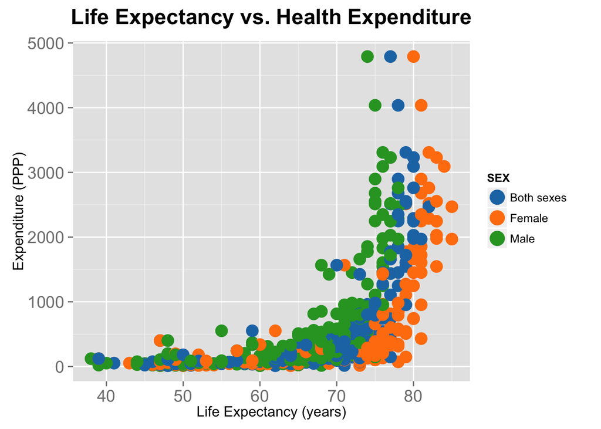

### Right Join

*Load Data Frames*

```r
source("../01 Data/right_join.R", echo=FALSE)
```

In the first table, the data displays the specific World Bank Income Group for each World Health Organization Region, and the second table contains information on the average healthcare expenditure per capita for each WHO Region.

World Bank Income Group by World Health Organization Region

| COUNTRY | WHO_REGION | WORLD_BANK_INCOME_GROUP |
| --- | --- | --- |
| Cameroon | Africa | Lower-middle-income |
| Sri Lanka | South-East Asia | Lower-middle-income |
| Austria | Europe | High-income |
| Bahamas | Americas | High-income |
| Barbados | Americas | High-income |
| Denmark | Europe | High-income |

Health Expenditure per capita by Region and Country

| COUNTRY | WHO_REGION | EXPENDITURE |
| --- | --- | --- |
| United States of America | Americas | 4790.0 |
| Luxembourg | Europe | 4036.5 |
| Norway | Europe | 3308.7 |
| Switzerland | Europe | 3230.0 |
| Monaco | Europe | 3091.4 |
| Austria | Europe | 2897.5 |

The right join function was used here to try to discover which WHO Region spends the most on healthcare per capita. The right join of the data sets produced the average expenditure on health per capita based on the WHO Region.

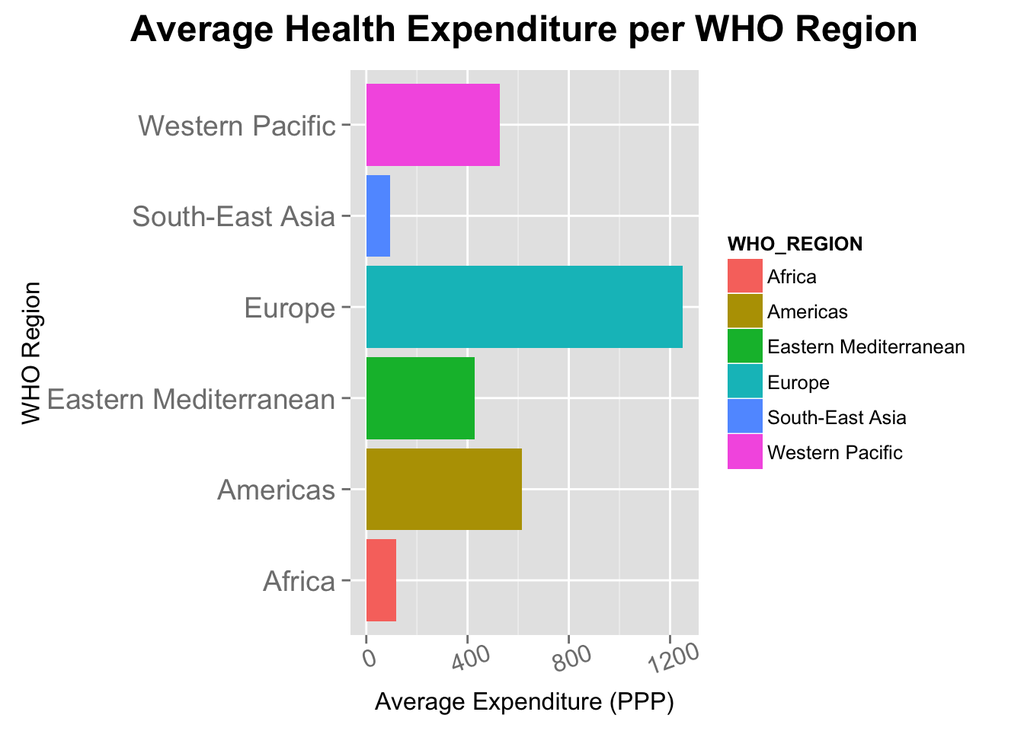

### Full Join

*Load Data Frames*

```r
source("../01 Data/full_join.R", echo=FALSE)
```

The following data displays the income group of each country for Both Sexes for the year 2012 in the first table. In the second table, the region of each country is recorded for the year 2012.

Country and Income Group

| YEAR | COUNTRY | WORLD_BANK_INCOME_GROUP |
| --- | --- | --- |
| 2012 | Cameroon | Lower-middle-income |
| 2012 | Guyana | Lower-middle-income |
| 2012 | Iraq | Lower-middle-income |
| 2012 | Sri Lanka | Lower-middle-income |
| 2012 | Austria | High-income |
| 2012 | Japan | High-income |

Country and Region

| YEAR | COUNTRY | WHO_REGION |
| --- | --- | --- |
| 2012 | Monaco | Europe |
| 2012 | Norway | Europe |
| 2012 | Guinea-Bissau | Africa |
| 2012 | Niger | Africa |
| 2012 | Burundi | Africa |
| 2012 | Sierra Leone | Africa |

The data was joined using an full join.. The joined data was used to create a plot of the regions on the y-axis and countries on the x-axis. The legend informs the reader that the plot is for data collected in 2012, as well as the color codes for all of the levels of income of each country captured in the data.

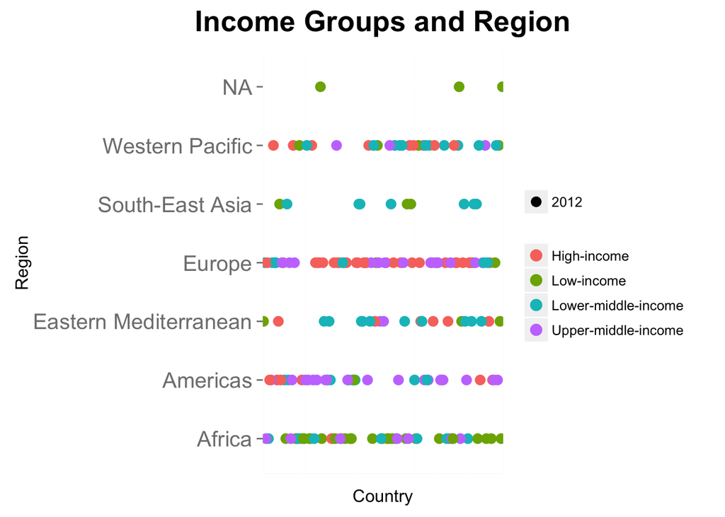

*The following are graphs made using lists and functions from the* **ListsForIfFunctionsPNG.R file** *, and they may not make much sense.* *They were made to experiment with functions and list*

### Categorical Columns

*Categorical variables shown here*: **Indicator, WHO Region, and Country**

```r
source("../03 Visualizations/categoricals.R", echo=FALSE)
```

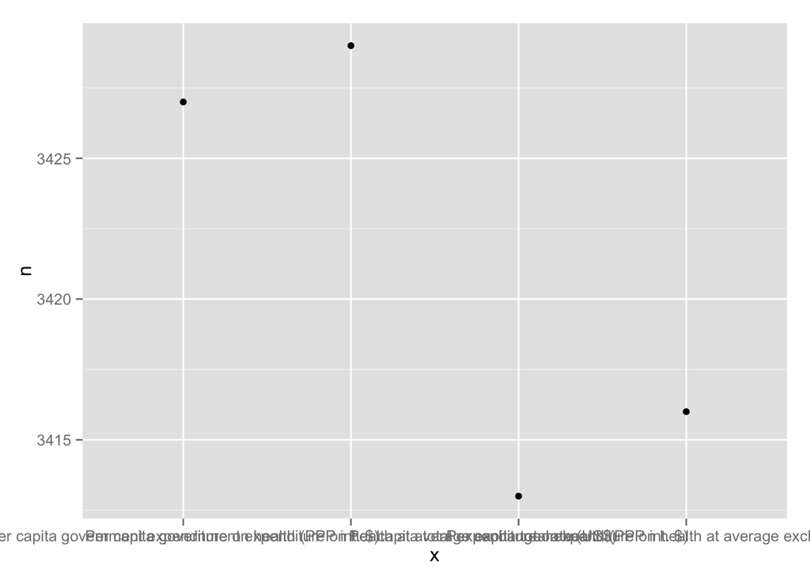

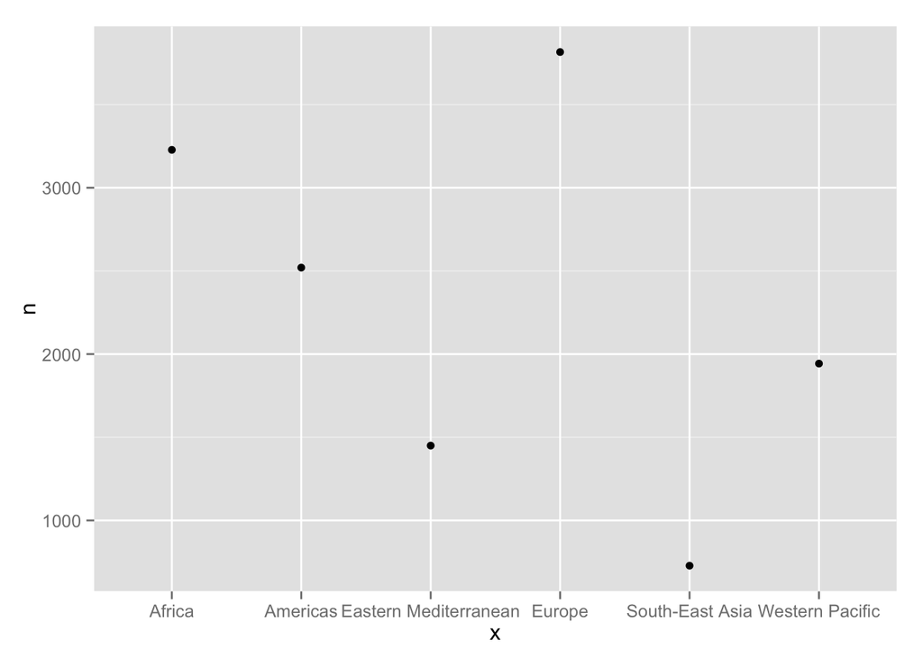

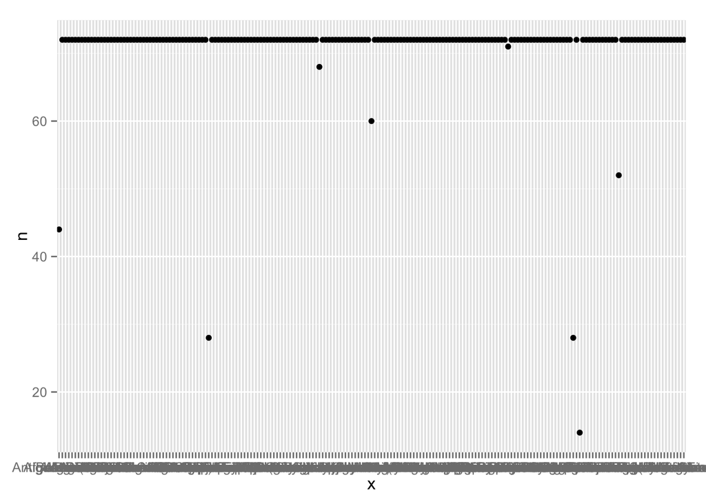

### Measure Columns

*Quantative variables shown here*: **Year and Health Expenditure**

```r
source("../03 Visualizations/measures.R", echo=FALSE)
```

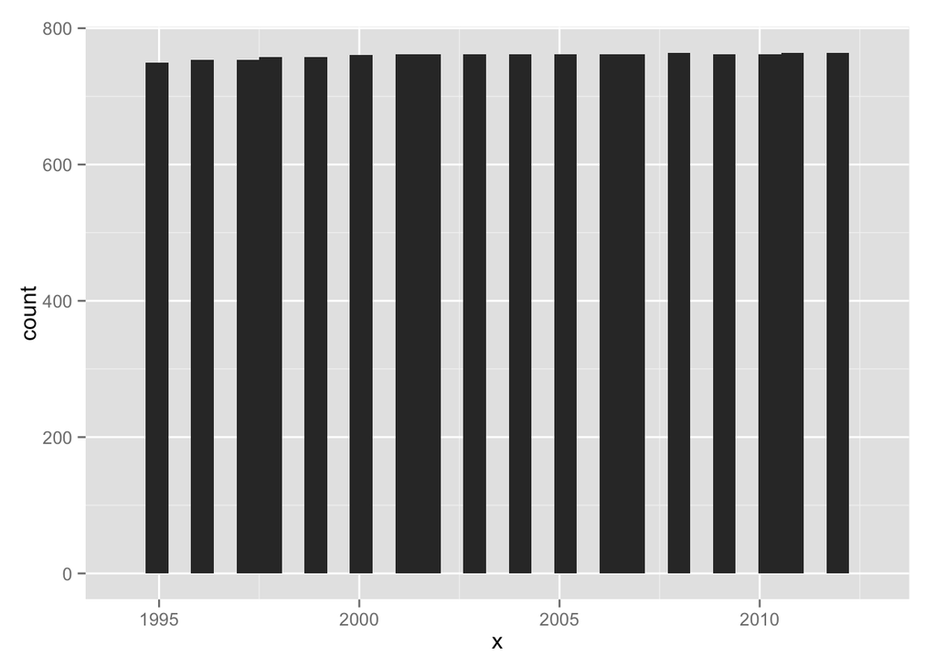

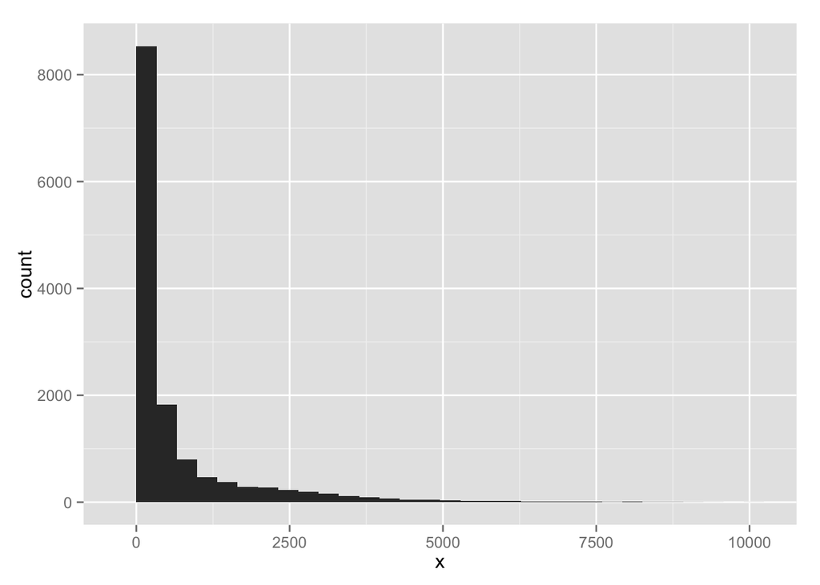